# Unsupervised Learning

# Sparse Random Projection

- sparse version of Random Projection
- it retains some degree of sparsity in the transformed feature set and is generally much more efficient, transforming the original data into the reduced space much faster than normal Gaussian random projection

```python
#https://scikit-learn.org/stable/modules/generated/sklearn.random_projection.SparseRandomProjection.html
from sklearn.random_projection import SparseRandomProjection

SRP = SparseRandomProjection(n_components=2, eps = 0.5)

vectors_ = SRP.fit_transform(X)

df_2 = pd.DataFrame(vectors_)

vectors_df = pd.concat([df_2,iris],axis=1).rename(columns = {0:'Vector 1',1:'Vector 2'})
vectors_df.head(5)
```

|  | Vector 1 | Vector 2 | sepal length | sepal width | petal length | petal width | target |
| --- | --- | --- | --- | --- | --- | --- | --- |
| 0 | -0.131376 | 0.619762 | 5.1 | 3.5 | 1.4 | 0.2 | Iris-setosa |
| 1 | 1.267975 | -0.294917 | 4.9 | 3.0 | 1.4 | 0.2 | Iris-setosa |
| 2 | 1.047504 | 0.410224 | 4.7 | 3.2 | 1.3 | 0.2 | Iris-setosa |
| 3 | 1.400075 | 0.299989 | 4.6 | 3.1 | 1.5 | 0.2 | Iris-setosa |
| 4 | -0.241611 | 0.972333 | 5.0 | 3.6 | 1.4 | 0.2 | Iris-setosa |

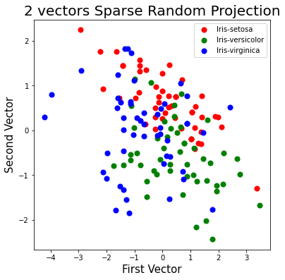

```python
fig = plt.figure(figsize = (6,6))
ax = fig.add_subplot(1,1,1)
ax.set_xlabel('First Vector', fontsize = 15)
ax.set_ylabel('Second Vector', fontsize = 15)
ax.set_title('2 vectors Sparse Random Projection', fontsize = 20)

targets = ['Iris-setosa', 'Iris-versicolor', 'Iris-virginica']
colors = ['r', 'g', 'b']
for target, color in zip(targets,colors):
    indicesToKeep = vectors_df['target'] == target
    ax.scatter(vectors_df.loc[indicesToKeep, 'Vector 1'],
               vectors_df.loc[indicesToKeep, 'Vector 2'], c = color, s = 50)
ax.legend(targets)
fig.show()
```

# Manifold Learning

- can be thought of as an attempt to generalize linear frameworks like PCA to be sensitive to non-linear structure in data
- manifold are smooth, curved surfaces within the multidimensional space

# ISOMAP

- it learns the intrinsic geometry of the original data based on where each point lies relative to its neighbors on a manifold

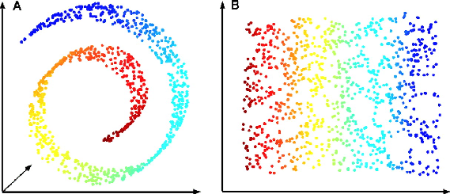

```python
#https://scikit-learn.org/stable/modules/generated/sklearn.manifold.Isomap.html
from sklearn.manifold import Isomap

isomap = Isomap(n_neighbors = 2)

vectors_ = isomap.fit_transform(X)

df_2 = pd.DataFrame(vectors_)

vectors_df = pd.concat([df_2,iris],axis=1).rename(columns = {0:'Vector 1',1:'Vector 2'})
vectors_df.head(5)
```

|  | Vector 1 | Vector 2 | sepal length | sepal width | petal length | petal width | target |
| --- | --- | --- | --- | --- | --- | --- | --- |
| 0 | -2.734078 | -1.630961 | 5.1 | 3.5 | 1.4 | 0.2 | Iris-setosa |
| 1 | -3.818955 | -0.263274 | 4.9 | 3.0 | 1.4 | 0.2 | Iris-setosa |
| 2 | -4.161307 | -0.009182 | 4.7 | 3.2 | 1.3 | 0.2 | Iris-setosa |
| 3 | -3.829926 | 0.004022 | 4.6 | 3.1 | 1.5 | 0.2 | Iris-setosa |
| 4 | -2.909981 | -1.596286 | 5.0 | 3.6 | 1.4 | 0.2 | Iris-setosa |

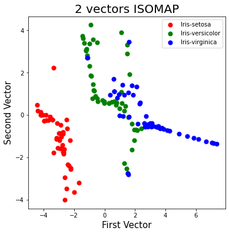

```python
fig = plt.figure(figsize = (6,6))
ax = fig.add_subplot(1,1,1)
ax.set_xlabel('First Vector', fontsize = 15)
ax.set_ylabel('Second Vector', fontsize = 15)
ax.set_title('2 vectors ISOMAP', fontsize = 20)

targets = ['Iris-setosa', 'Iris-versicolor', 'Iris-virginica']
colors = ['r', 'g', 'b']
for target, color in zip(targets,colors):
    indicesToKeep = vectors_df['target'] == target
    ax.scatter(vectors_df.loc[indicesToKeep, 'Vector 1'],
               vectors_df.loc[indicesToKeep, 'Vector 2'], c = color, s = 50)
ax.legend(targets)
fig.show()
```

# Locally Linear Embedding

- this method preserves distances within local neighborhoods as it projects the data from the original feature space to a reduced space
- LLE discovers the nonlinear structure in the original high-dimensional data by segmenting the data into smaller components and modeling each component as a linear embedding

```python
#https://scikit-learn.org/stable/modules/generated/sklearn.manifold.LocallyLinearEmbedding.html
from sklearn.manifold import LocallyLinearEmbedding

lle = LocallyLinearEmbedding(n_components = 2, n_neighbors=5, method='modified')

vectors_ = lle.fit_transform(X)

df_2 = pd.DataFrame(vectors_)

vectors_df = pd.concat([df_2,iris],axis=1).rename(columns = {0:'Vector 1',1:'Vector 2'})
vectors_df.head(5)
```

|  | Vector 1 | Vector 2 | sepal length | sepal width | petal length | petal width | target |
| --- | --- | --- | --- | --- | --- | --- | --- |
| 0 | -0.119706 | 0.084064 | 5.1 | 3.5 | 1.4 | 0.2 | Iris-setosa |
| 1 | -0.096589 | -0.180992 | 4.9 | 3.0 | 1.4 | 0.2 | Iris-setosa |
| 2 | -0.112955 | -0.212583 | 4.7 | 3.2 | 1.3 | 0.2 | Iris-setosa |
| 3 | -0.108216 | -0.200033 | 4.6 | 3.1 | 1.5 | 0.2 | Iris-setosa |
| 4 | -0.120757 | 0.098891 | 5.0 | 3.6 | 1.4 | 0.2 | Iris-setosa |

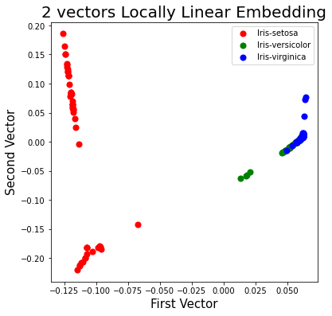

```python
fig = plt.figure(figsize = (6,6))
ax = fig.add_subplot(1,1,1)
ax.set_xlabel('First Vector', fontsize = 15)
ax.set_ylabel('Second Vector', fontsize = 15)
ax.set_title('2 vectors Locally Linear Embedding', fontsize = 20)

targets = ['Iris-setosa', 'Iris-versicolor', 'Iris-virginica']
colors = ['r', 'g', 'b']
for target, color in zip(targets,colors):
    indicesToKeep = vectors_df['target'] == target
    ax.scatter(vectors_df.loc[indicesToKeep, 'Vector 1'],
               vectors_df.loc[indicesToKeep, 'Vector 2'], c = color, s = 50)
ax.legend(targets)
fig.show()
```

# t-Distributed Stocastic Neighbor Embedding

- embeds high-dimensional data into a space of just two or three dimensions
- similar instances are modeled closer together and dissimilar instances are modeled further away
- t-SNE has a nonconvex cost function, which means that different initializations of the algorithm will generate different results $\rightarrow\$ no stable solution
- in real-world applications of t-SNE, it is best to use another dimensionality reduction technique (such as PCA) to reduce the number of dimensions before applying t-SNE. In this way we reduce the noise in the features that are fed into t-SNE and speed up the computation of the algorithm

```python
from sklearn.manifold import TSNE
#https://scikit-learn.org/stable/modules/generated/sklearn.manifold.TSNE.html

tSNE = TSNE()

vectors_ = tSNE.fit_transform(X)

df_2 = pd.DataFrame(vectors_)

vectors_df = pd.concat([df_2,iris],axis=1).rename(columns = {0:'Vector 1',1:'Vector 2'})
vectors_df.head(5)
```

|  | Vector 1 | Vector 2 | sepal length | sepal width | petal length | petal width | target |
| --- | --- | --- | --- | --- | --- | --- | --- |
| 0 | 23.132933 | 9.034410 | 5.1 | 3.5 | 1.4 | 0.2 | Iris-setosa |
| 1 | 19.567116 | 8.266977 | 4.9 | 3.0 | 1.4 | 0.2 | Iris-setosa |
| 2 | 20.433306 | 9.371036 | 4.7 | 3.2 | 1.3 | 0.2 | Iris-setosa |
| 3 | 19.691919 | 9.318096 | 4.6 | 3.1 | 1.5 | 0.2 | Iris-setosa |
| 4 | 23.676100 | 8.928338 | 5.0 | 3.6 | 1.4 | 0.2 | Iris-setosa |

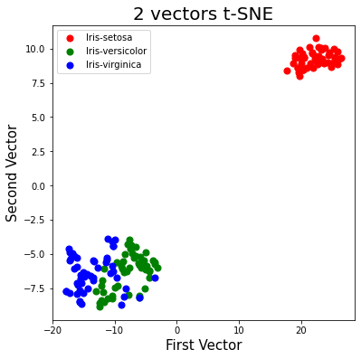

```python
fig = plt.figure(figsize = (6,6))
ax = fig.add_subplot(1,1,1)
ax.set_xlabel('First Vector', fontsize = 15)
ax.set_ylabel('Second Vector', fontsize = 15)
ax.set_title('2 vectors t-SNE', fontsize = 20)

targets = ['Iris-setosa', 'Iris-versicolor', 'Iris-virginica']
colors = ['r', 'g', 'b']
for target, color in zip(targets,colors):
    indicesToKeep = vectors_df['target'] == target
    ax.scatter(vectors_df.loc[indicesToKeep, 'Vector 1'],
               vectors_df.loc[indicesToKeep, 'Vector 2'], c = color, s = 50)
ax.legend(targets)
fig.show()
```

# Other Type of Reduction

# Dictionary Learning

- learns the sparse representation of the original data.
- the matrix (known as the dictionary) is mostly populated by zeros with only a few nonzero weights
- the vectors in the dictionary are known as atoms
- identify the most salient representative elements of the original feature space and these are the ones that have the most nonzero weights

```python
from sklearn.decomposition import DictionaryLearning
#https://scikit-learn.org/stable/modules/generated/sklearn.decomposition.DictionaryLearning.html

dictionarylearning = DictionaryLearning(n_components = 2)

vectors_ = dictionarylearning.fit_transform(X)

df_2 = pd.DataFrame(vectors_)

vectors_df = pd.concat([df_2,iris],axis=1).rename(columns = {0:'Vector 1',1:'Vector 2'})
vectors_df.head(5)
```

|  | Vector 1 | Vector 2 | sepal length | sepal width | petal length | petal width | target |
| --- | --- | --- | --- | --- | --- | --- | --- |
| 0 | 0.000000 | 2.212289 | 5.1 | 3.5 | 1.4 | 0.2 | Iris-setosa |
| 1 | -2.179479 | 0.000000 | 4.9 | 3.0 | 1.4 | 0.2 | Iris-setosa |
| 2 | -2.332623 | 0.000000 | 4.7 | 3.2 | 1.3 | 0.2 | Iris-setosa |
| 3 | -2.362678 | 0.000000 | 4.6 | 3.1 | 1.5 | 0.2 | Iris-setosa |
| 4 | 0.000000 | 2.403663 | 5.0 | 3.6 | 1.4 | 0.2 | Iris-setosa |

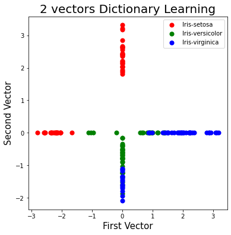

```python
fig = plt.figure(figsize = (6,6))
ax = fig.add_subplot(1,1,1)
ax.set_xlabel('First Vector', fontsize = 15)
ax.set_ylabel('Second Vector', fontsize = 15)
ax.set_title('2 vectors Dictionary Learning', fontsize = 20)

targets = ['Iris-setosa', 'Iris-versicolor', 'Iris-virginica']
colors = ['r', 'g', 'b']
for target, color in zip(targets,colors):
    indicesToKeep = vectors_df['target'] == target
    ax.scatter(vectors_df.loc[indicesToKeep, 'Vector 1'],
               vectors_df.loc[indicesToKeep, 'Vector 2'], c = color, s = 50)
ax.legend(targets)
fig.show()
```

# Indipendent Component Analysis

- is commonly used in signal processing tasks (for example, to identify the individual voices in an audio clip of a busy coffeehouse)
- the blended signals are separate into their individual components and after the separation is complete, any original characteristic is reconstructed by adding some combination of the individual components that are generated

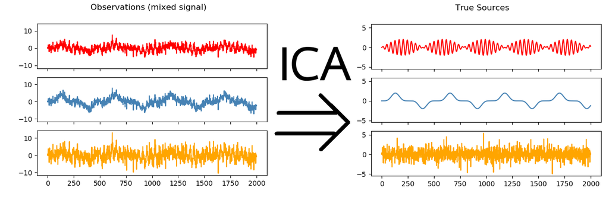

```python
from sklearn.decomposition import FastICA
#https://scikit-learn.org/stable/modules/generated/sklearn.decomposition.FastICA.html

fastICA = FastICA(n_components=2, algorithm = 'parallel')

vectors_ = fastICA.fit_transform(X)

df_2 = pd.DataFrame(vectors_)

vectors_df = pd.concat([df_2,iris],axis=1).rename(columns = {0:'Vector 1',1:'Vector 2'})
vectors_df.head(5)
```

|  | Vector 1 | Vector 2 | sepal length | sepal width | petal length | petal width | target |
| --- | --- | --- | --- | --- | --- | --- | --- |
| 0 | -0.106742 | -0.046925 | 5.1 | 3.5 | 1.4 | 0.2 | Iris-setosa |
| 1 | -0.101808 | 0.052094 | 4.9 | 3.0 | 1.4 | 0.2 | Iris-setosa |
| 2 | -0.114232 | 0.022962 | 4.7 | 3.2 | 1.3 | 0.2 | Iris-setosa |
| 3 | -0.111976 | 0.044912 | 4.6 | 3.1 | 1.5 | 0.2 | Iris-setosa |
| 4 | -0.112162 | -0.061513 | 5.0 | 3.6 | 1.4 | 0.2 | Iris-setosa |

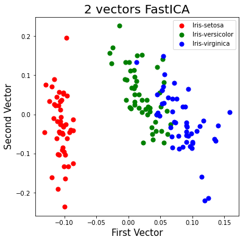

```python
fig = plt.figure(figsize = (6,6))
ax = fig.add_subplot(1,1,1)
ax.set_xlabel('First Vector', fontsize = 15)
ax.set_ylabel('Second Vector', fontsize = 15)
ax.set_title('2 vectors FastICA', fontsize = 20)

targets = ['Iris-setosa', 'Iris-versicolor', 'Iris-virginica']
colors = ['r', 'g', 'b']
for target, color in zip(targets,colors):
    indicesToKeep = vectors_df['target'] == target
    ax.scatter(vectors_df.loc[indicesToKeep, 'Vector 1'],
               vectors_df.loc[indicesToKeep, 'Vector 2'], c = color, s = 50)
ax.legend(targets)
fig.show()
```

# Challenge!

Now it is your turn! On the [github](https://github.com/DSS-ML/Unsupervised) repository you will find a dataset on *pokemon*. In groups of two or three, work together to find out which reduction algorithm would be most suitable and especially which target type to consider in order to compare the results (Legend, Mega, Type1,Type2, Generation) (?)

p.s. An EDA is appreciated :)